# Kidney disease dataset EDA

# Running PCA and training ML model to predict chronic and not chronic

[figure not shown]

```python
kidney=kidney[['rc','wc','bgr','hemo','pcv','bu','sc','sod','pot','su','al','sg','bp','age','classification']]
```

# Coorelation map of various factors

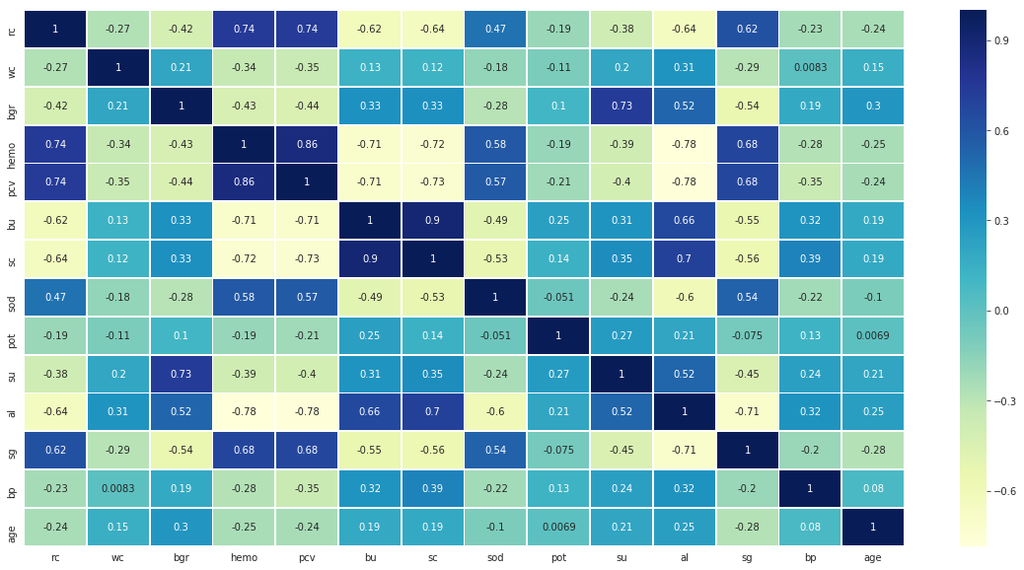

```python
plt.figure(1,figsize=(20,10))
sns.heatmap(kidney.corr(),annot=True,cmap='YlGnBu',linewidth=0.8)
plt.show()
```

```python
scaleFeatures = False





labels = ['red' if i=='ckd' else 'green' for i in kidney.classification]


df = kidney[['bgr', 'wc', 'rc']]


df.head(10)
```

|  | bgr | wc | rc |
| --- | --- | --- | --- |
| 3 | 117.0 | 6700.0 | 3.9 |
| 9 | 70.0 | 12100.0 | 3.7 |
| 11 | 380.0 | 4500.0 | 3.8 |
| 14 | 157.0 | 11000.0 | 2.6 |
| 20 | 173.0 | 9200.0 | 3.2 |
| 22 | 95.0 | 6900.0 | 3.4 |
| 27 | 264.0 | 9600.0 | 4.1 |
| 48 | 70.0 | 18900.0 | 3.5 |
| 58 | 253.0 | 7200.0 | 4.3 |
| 71 | 163.0 | 14600.0 | 3.2 |

```python
df.dtypes
```

```
bgr    float64
wc     float64
rc     float64
dtype: object
```

```python
print(df.var())
print("This is the describe output: ", df.describe())
```

```
bgr    4.217182e+03
wc     9.777380e+06
rc     1.039104e+00
dtype: float64
This is the describe output:                bgr            wc          rc
count  158.000000    158.000000  158.000000
mean   131.341772   8475.949367    4.891772
std     64.939832   3126.880181    1.019364
min     70.000000   3800.000000    2.100000
25%     97.000000   6525.000000    4.500000
50%    115.500000   7800.000000    4.950000
75%    131.750000   9775.000000    5.600000
max    490.000000  26400.000000    8.000000
```

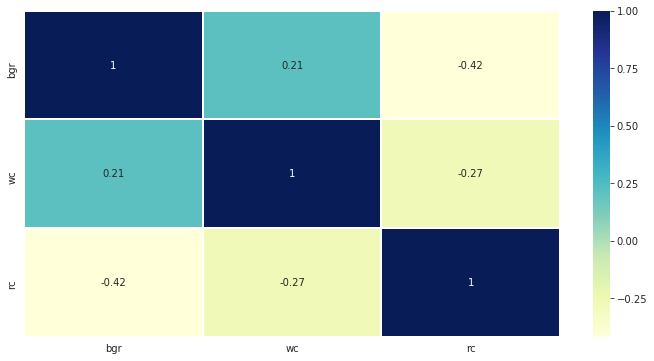

```python
plt.figure(1,figsize=(12,6))
sns.heatmap(df.corr(),annot=True,cmap='YlGnBu',linewidth=0.8)
plt.show()
```

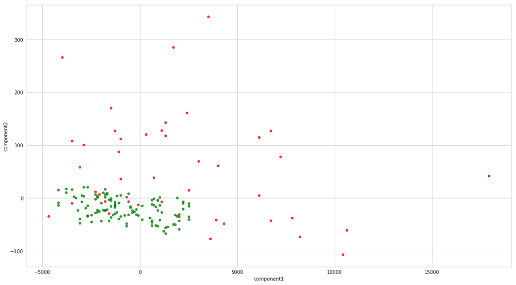

```python
if scaleFeatures: df = helper.scaleFeatures(df)


from sklearn.decomposition import PCA
pca = PCA(n_components = 2)
pca.fit(df)
T = pca.transform(df)

plt.figure(1, figsize=(18,10))
ax = helper.drawVectors(T, pca.components_, df.columns.values, plt, scaleFeatures)
T = pd.DataFrame(T)
T.columns = ['component1', 'component2']
T.plot.scatter(x='component1', y='component2', marker='o', c=labels, alpha=0.75, ax=ax)
plt.show()
```

# Scatter plot of PCA performed dataset

- As you can see Not chronic kidney diseases in green are easily separable from chronic kidney disease.
- Some results are mixed

# Although the dataset has reduced after cleaning but lets train it anyway.

```python
kidney.head()
```

[output not shown]

```python
def cl(x):
  if x=='ckd':
    return 1
  elif x=='notckd':
    return 0
```

```python
kidney.classification=kidney.classification.apply(cl,convert_dtype=True)
```

```python
kidney.dtypes
```

```
rc                float64
wc                float64
bgr               float64
hemo              float64
pcv               float64
bu                float64
sc                float64
sod               float64
pot               float64
su                float64
al                float64
sg                float64
bp                float64
age               float64
classification      int64
dtype: object
```

```python
from sklearn.metrics import accuracy_score
from sklearn.model_selection import train_test_split
from sklearn.tree import DecisionTreeClassifier
```

```python
clean_data=kidney.copy()
```

```python
y=clean_data[['classification']].copy()
```

```python
y.head()
```

|  | classification |
| --- | --- |
| 3 | 1 |
| 9 | 1 |
| 11 | 1 |
| 14 | 1 |
| 20 | 1 |

```python
kidney.columns
```

```
Index(['rc', 'wc', 'bgr', 'hemo', 'pcv', 'bu', 'sc', 'sod', 'pot', 'su', 'al',
       'sg', 'bp', 'age', 'classification'],
      dtype='object')
```

```python
X = clean_data[['rc', 'wc', 'bgr', 'hemo', 'pcv', 'bu', 'sc', 'sod', 'pot', 'su', 'al',
       'sg', 'bp', 'age']].copy()
```

```python
X.head()
```

|  | rc | wc | bgr | hemo | pcv | bu | sc | sod | pot | su | al | sg | bp | age |
| --- | --- | --- | --- | --- | --- | --- | --- | --- | --- | --- | --- | --- | --- | --- |
| 3 | 3.9 | 6700.0 | 117.0 | 11.2 | 32.0 | 56.0 | 3.8 | 111.0 | 2.5 | 0.0 | 4.0 | 1.005 | 70.0 | 48.0 |
| 9 | 3.7 | 12100.0 | 70.0 | 9.5 | 29.0 | 107.0 | 7.2 | 114.0 | 3.7 | 0.0 | 2.0 | 1.020 | 90.0 | 53.0 |
| 11 | 3.8 | 4500.0 | 380.0 | 10.8 | 32.0 | 60.0 | 2.7 | 131.0 | 4.2 | 0.0 | 3.0 | 1.010 | 70.0 | 63.0 |
| 14 | 2.6 | 11000.0 | 157.0 | 5.6 | 16.0 | 90.0 | 4.1 | 130.0 | 6.4 | 2.0 | 3.0 | 1.010 | 80.0 | 68.0 |
| 20 | 3.2 | 9200.0 | 173.0 | 7.7 | 24.0 | 148.0 | 3.9 | 135.0 | 5.2 | 0.0 | 2.0 | 1.015 | 80.0 | 61.0 |

```python
X.shape
```

```
(158, 14)
```

```python
 X_train, X_test, y_train, y_test = train_test_split(X, y, test_size=0.5,random_state=324)
```

```python
print(type(X_train))
print(type(X_test))
print(type(y_train))
print(type(y_test))


y_train.describe()
```

```
<class 'pandas.core.frame.DataFrame'>
<class 'pandas.core.frame.DataFrame'>
<class 'pandas.core.frame.DataFrame'>
<class 'pandas.core.frame.DataFrame'>
```

|  | classification |
| --- | --- |
| count | 79.000000 |
| mean | 0.253165 |
| std | 0.437603 |
| min | 0.000000 |
| 25% | 0.000000 |
| 50% | 0.000000 |
| 75% | 0.500000 |
| max | 1.000000 |

```python
X_train.head()
```

[output not shown]

```python
X_train.shape
```

[output not shown]

```python
y_train.shape
```

[output not shown]

```python
kidney_classifier = DecisionTreeClassifier(max_leaf_nodes=10, random_state=0)
kidney_classifier.fit(X_train, y_train)
```

```
DecisionTreeClassifier(class_weight=None, criterion='gini', max_depth=None,
                       max_features=None, max_leaf_nodes=10,
                       min_impurity_decrease=0.0, min_impurity_split=None,
                       min_samples_leaf=1, min_samples_split=2,
                       min_weight_fraction_leaf=0.0, presort=False,
                       random_state=0, splitter='best')
```

```python
type(kidney_classifier)
```

```
sklearn.tree.tree.DecisionTreeClassifier
```

```python
predictions = kidney_classifier.predict(X_test)
```

```python
predictions[:10]
```

```
array([0, 0, 1, 0, 0, 1, 0, 0, 0, 1])
```

```python
y_test['classification'][:10]
```

```
358    0
266    0
74     1
393    0
347    0
76     1
380    0
394    0
341    0
128    1
Name: classification, dtype: int64
```

```python
accuracy_score(y_true = y_test, y_pred = predictions)
```

```
0.9873417721518988
```

# This is what happens when you have a small dataset and too many features.

- It's is here showing an accuracy score of **98%**.